# Decision Tree implementation using R

### *Rajan Kataria (18103076)*

In this notebook, we are implementimg the decision tree algorithm using Information gain and Gini index as a splitting criterion. The dataset that has been used is a balance-scale dataset taken from https://archive.ics.uci.edu/ml/machine-learning-databases/balance-scale/ . The dataset was manually converted from .data to .csv format after downloading from the mentioned link.

## **R Library Import**

**Importing different libraries required for the implementation:**

```r
library(ggplot2)
library(lattice)
library(lava)
library(purrr)
library(caret)
library(rpart)
library(rpart.plot)
library(ggthemes)
```

## **Dataset Import**

**Importing the data-set in the .csv format using read.csv() function:**

```r
df<- read.csv("C:/Users/Asus/Desktop/ML_18103076/balance_scale.csv")
```

## **Exploring dataset**

**Checking the structure of dataset using str() function:**

```r
str(df)
```

```
## 'data.frame':    625 obs. of  5 variables:
##  $ Left.Weight   : int  1 1 1 1 1 1 1 1 1 1 ...
##  $ Left.Distance : int  1 1 1 1 1 1 1 1 1 1 ...
##  $ Right.Weight  : int  1 1 1 1 1 2 2 2 2 2 ...
##  $ Right.Distance: int  1 2 3 4 5 1 2 3 4 5 ...
##  $ Class.Name    : Factor w/ 3 levels "B","L","R": 1 3 3 3 3 3 3 3 3 3 ...
```

**Checking the head of the dataset using head().**

```r
head(df)
```

|  | Left.Weight | Left.Distance | Right.Weight | Right.Distance | Class.Name |
| --- | --- | --- | --- | --- | --- |
| 1 | 1 | 1 | 1 | 1 | B |
| 2 | 1 | 1 | 1 | 2 | R |
| 3 | 1 | 1 | 1 | 3 | R |
| 4 | 1 | 1 | 1 | 4 | R |
| 5 | 1 | 1 | 1 | 5 | R |
| 6 | 1 | 1 | 2 | 1 | R |

**Checking the unique values of all the columns using unique() function in order to see what values are taken by the variables:**

```r
unique(df$Left.Weight)
```

```
## [1] 1 2 3 4 5
```

```r
unique(df$ Left.Distance)
```

```
## [1] 1 2 3 4 5
```

```r
unique(df$Right.Weight)
```

```
## [1] 1 2 3 4 5
```

```r
unique(df$Right.Distance)
```

```
## [1] 1 2 3 4 5
```

```r
unique(df$Class.Name)
```

```
## [1] B R L
## Levels: B L R
```

**Converting the factor value into integer bt taking the entire dataset into some temporary variable in order to check the correlation between the different variables or attributes using cor() function:**

```r
df.int<-df
df.int$Class.Name= as.integer(df.int$Class.Name)
cor(df.int)
```

```
##                Left.Weight Left.Distance Right.Weight Right.Distance Class.Name
## Left.Weight      1.0000000     0.0000000    0.0000000      0.0000000 -0.3068132
## Left.Distance    0.0000000     1.0000000    0.0000000      0.0000000 -0.3068132
## Right.Weight     0.0000000     0.0000000    1.0000000      0.0000000  0.3230563
## Right.Distance   0.0000000     0.0000000    0.0000000      1.0000000  0.3230563
## Class.Name      -0.3068132    -0.3068132    0.3230563      0.3230563  1.0000000
```

**As all the variables i.e. Left.Weight, Left.Distance, Right.Weight and Right.Distance are taking only the values 1, 2, 3, 4, 5; we converted all of them into factor data type as now the whole dataset has become the nominal dataset and the Class.Name atribute was initially factor having 3 classes.**

```r
df.copy<-df
df.copy$Left.Weight= as.factor(df.copy$Left.Weight)
df.copy$Left.Distance= as.factor(df.copy$Left.Distance)
df.copy$Right.Weight= as.factor(df.copy$Right.Weight)
df.copy$Right.Distance= as.factor(df.copy$Right.Distance)
str(df.copy)
```

```
## 'data.frame':    625 obs. of  5 variables:
##  $ Left.Weight   : Factor w/ 5 levels "1","2","3","4",..: 1 1 1 1 1 1 1 1 1 1 ...
##  $ Left.Distance : Factor w/ 5 levels "1","2","3","4",..: 1 1 1 1 1 1 1 1 1 1 ...
##  $ Right.Weight  : Factor w/ 5 levels "1","2","3","4",..: 1 1 1 1 1 2 2 2 2 2 ...
##  $ Right.Distance: Factor w/ 5 levels "1","2","3","4",..: 1 2 3 4 5 1 2 3 4 5 ...
##  $ Class.Name    : Factor w/ 3 levels "B","L","R": 1 3 3 3 3 3 3 3 3 3 ...
```

**Checking the summary of dataet formed after conversion of attributes into factor type:**

```r
summary(df.copy)
```

```
##  Left.Weight Left.Distance Right.Weight Right.Distance Class.Name
##  1:125       1:125         1:125        1:125          B: 49
##  2:125       2:125         2:125        2:125          L:288
##  3:125       3:125         3:125        3:125          R:288
##  4:125       4:125         4:125        4:125
##  5:125       5:125         5:125        5:125
```

## **Visualizing Dataset**

**Plotting a bar plot and checking the count of each class division:**

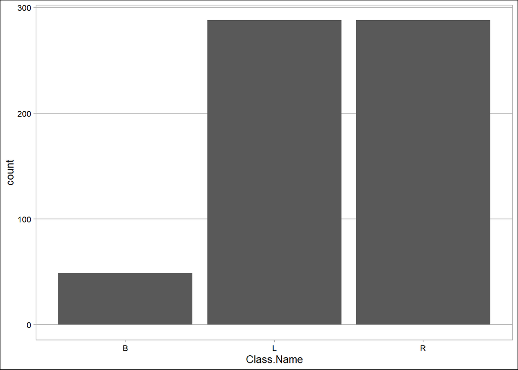

```r
pl<-ggplot(df.copy, aes(x=Class.Name))
pl+ geom_bar()+theme_calc()
```

**Plotting the entire dataset:**

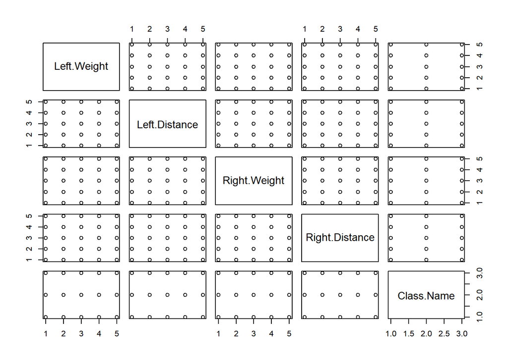

```r
plot(df.copy)
```

## **Pre-process data (Handling missing values)**

**Checking the dataset for having any missing values:**

```r
sum(is.na(df.copy))
```

```
## [1] 0
```

```r
mean(is.na(df.copy))
```

```
## [1] 0
```

```r
#If missing values would have been found, we would have replaced them with the mean of the values in the respective cloumn
#for(i in 1:ncol(df.copy))
#{df.copy[is.na(df.copy[,i]), i] <- mean(df.copy[,i], na.rm = TRUE)}
```

## **Slicing the dataset**

**Slicing the data into training set and the test_set**

```r
#pod is partitioning of data here
pod= sample(2, nrow(df.copy), replace=TRUE, c(0.7, 0.3))
#putting the first index portion of pod in train_data
train_data=df.copy[pod==1,]
#putting the second index portion of pod in test_data
test_data=df.copy[pod==2,]
```

**Checking the dimensions of training dataset and testing dataset**

```r
dim(train_data)
```

```
## [1] 443   5
```

```r
dim(test_data)
```

```
## [1] 182   5
```

## **Training the dataset**

**Training a decision tree classifier using Information gain criterion and 10 fold cross validation on the training dataset:**

```r
tree.ctrl <- trainControl(method = "repeatedcv", number = 10, repeats = 3)
ig.dtree <- train(Class.Name ~., data = train_data, method = "rpart",
                   parms = list(split = "information"),
                   trControl=tree.ctrl,
                   tuneLength = 10)
```

**Checking the results of trained decision tree classifier using Information gain criterion:**

```r
ig.dtree
```

```
## CART
##
## 443 samples
##   4 predictor
##   3 classes: 'B', 'L', 'R'
##
## No pre-processing
## Resampling: Cross-Validated (10 fold, repeated 3 times)
## Summary of sample sizes: 400, 398, 398, 399, 398, 399, ...
## Resampling results across tuning parameters:
##
##   cp          Accuracy   Kappa
##   0.00000000  0.6463034  0.3486159
##   0.01587302  0.6227303  0.3007024
##   0.03174603  0.6049743  0.2684040
##   0.04761905  0.5952933  0.2528209
##   0.06349206  0.5772262  0.2209030
##   0.07936508  0.5698188  0.2091101
##   0.09523810  0.5659797  0.2104483
##   0.11111111  0.5659797  0.2104483
##   0.12698413  0.5621918  0.2016960
##   0.14285714  0.4950682  0.0632130
##
## Accuracy was used to select the optimal model using the largest value.
## The final value used for the model was cp = 0.
```

**Training a decision tree classifier using Gini index criterion and 10 fold cross validation on the training dataset:**

```r
set.seed(3333)
gini.dtree <- train(Class.Name~., data = train_data, method = "rpart",
                   parms = list(split = "gini"),
                   trControl=tree.ctrl,
                   tuneLength = 10)
```

**Checking the results of trained decision tree classifier using Gini index criterion:**

```r
gini.dtree
```

```
## CART
##
## 443 samples
##   4 predictor
##   3 classes: 'B', 'L', 'R'
##
## No pre-processing
## Resampling: Cross-Validated (10 fold, repeated 3 times)
## Summary of sample sizes: 399, 400, 397, 398, 399, 398, ...
## Resampling results across tuning parameters:
##
##   cp          Accuracy   Kappa
##   0.00000000  0.6397907  0.34039155
##   0.01587302  0.6215882  0.30127244
##   0.03174603  0.6365201  0.32435277
##   0.04761905  0.6126649  0.28364777
##   0.06349206  0.5944615  0.25481631
##   0.07936508  0.5907072  0.25022631
##   0.09523810  0.5892762  0.24960192
##   0.11111111  0.5892762  0.24960192
##   0.12698413  0.5825422  0.23820916
##   0.14285714  0.5110177  0.09097046
##
## Accuracy was used to select the optimal model using the largest value.
## The final value used for the model was cp = 0.
```

## **Plotting the decision trees**

**Plotting a decision tree formed by Information gain criterion:**

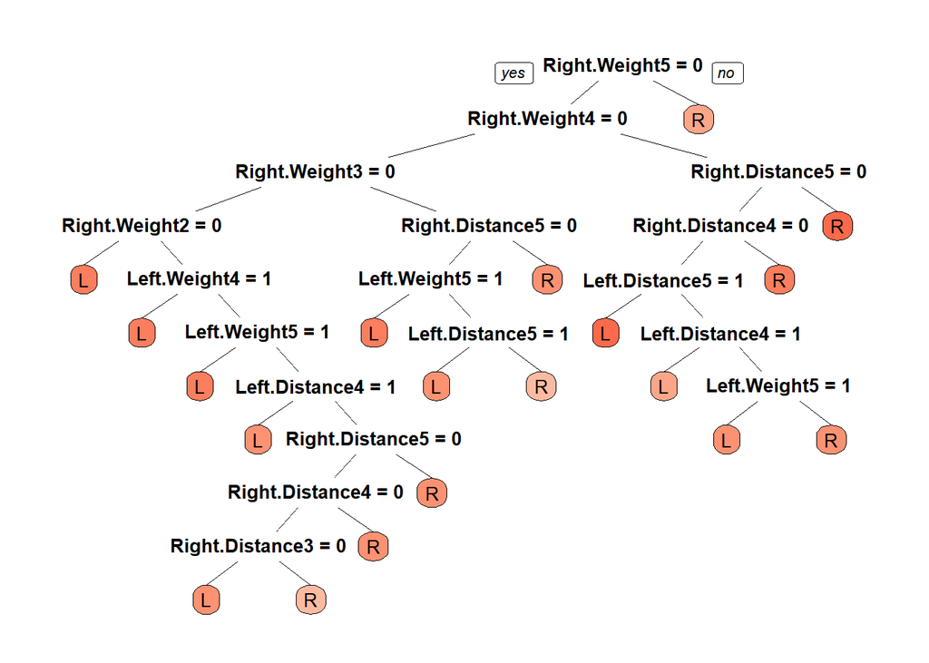

```r
prp(ig.dtree$finalModel, box.palette = "Reds", tweak = 1.0)
```

**Plotting a decision tree formed by Gini index criterion**

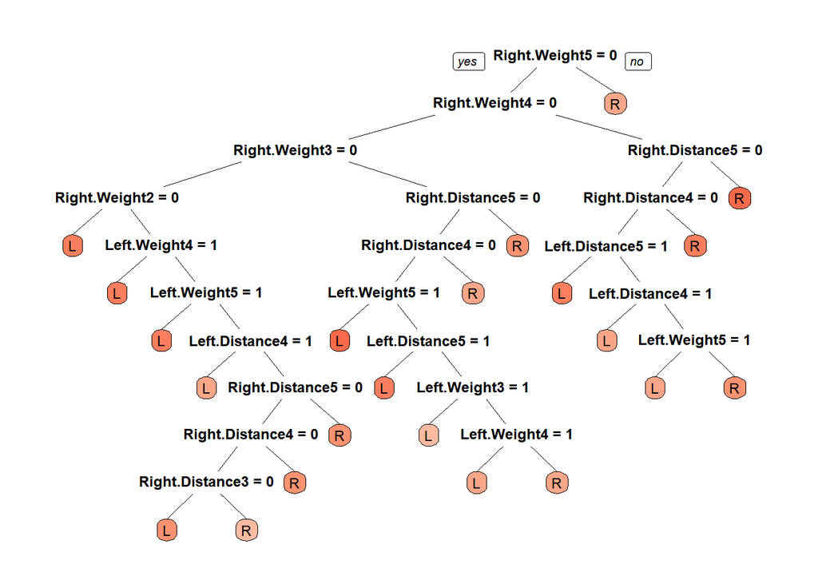

```r
prp(gini.dtree$finalModel, box.palette = "Reds", tweak = 1.0)
```

## **Prediction**

**Prediction of decision tree formed by Information gain criterion on the test dataset:**

```r
ig.dtree.predict<- predict(ig.dtree, test_data)
ig.dtree.predict
```

```
##   [1] L L L L R R R L L L L L R R R R R R L R R R R R L L R L R L L L R L L L L
##  [38] R R R R L R R R R R R R R R R R L L L L R R R R R L L L L L L R R R R R R
##  [75] L L R R R R L L R R R R R R R R R R L L R R R L L R R L L L L L L R R L L
## [112] L R R R R R R R R R R R L L R R L R L R L R R R R R R L L L L L L R R R R
## [149] R L L L L L L L L L L L L L L L L L L R R R L L L L L L L R L R R R
## Levels: B L R
```

**Predicted values converted into matrix:**

```r
con_mat<-table(ig.dtree.predict, test_data$Class.Name)
con_mat
```

```
##
## ig.dtree.predict  B  L  R
##                B  0  0  0
##                L  5 61 19
##                R  6 34 57
```

**Confusion matrix and statistics of the decision tree formed using information gain criterion:**

```r
confusionMatrix(ig.dtree.predict, test_data$Class.Name )
```

```
## Confusion Matrix and Statistics
##
##           Reference
## Prediction  B  L  R
##          B  0  0  0
##          L  5 61 19
##          R  6 34 57
##
## Overall Statistics
##
##                Accuracy : 0.6484
##                  95% CI : (0.5743, 0.7175)
##     No Information Rate : 0.522
##     P-Value [Acc > NIR] : 0.000381
##
##                   Kappa : 0.3411
##
##  Mcnemar's Test P-Value : 0.001619
##
## Statistics by Class:
##
##                      Class: B Class: L Class: R
## Sensitivity           0.00000   0.6421   0.7500
## Specificity           1.00000   0.7241   0.6226
## Pos Pred Value            NaN   0.7176   0.5876
## Neg Pred Value        0.93956   0.6495   0.7765
## Prevalence            0.06044   0.5220   0.4176
## Detection Rate        0.00000   0.3352   0.3132
## Detection Prevalence  0.00000   0.4670   0.5330
## Balanced Accuracy     0.50000   0.6831   0.6863
```

**Prediction of decision tree formed by Gini index criterion on the test dataset:**

```r
gini.dtree.predict<- predict(gini.dtree, test_data)
gini.dtree.predict
```

```
##   [1] L L L L R R R L L L L L R R R R R R L R R R R R L L R L R L L L R L L L L
##  [38] R R R R L R R R R R R R R R R R L L L L R R R R R L L L L L L R R L R R R
##  [75] L L L R R R L L R L R R R L R R R R L L R R R L R R R L L L L L L L R L L
## [112] L L R R R R R L R R R R L L L R L R L R L R R R R R R L L L L L L R R R R
## [149] R L L L L R L L L L L L L L L L L L R R R R L L L L L L R R L R R R
## Levels: B L R
```

**Predicted values converted into matrix:**

```r
con_mat2<-table(gini.dtree.predict, test_data$Class.Name)
con_mat2
```

```
##
## gini.dtree.predict  B  L  R
##                  B  0  0  0
##                  L  5 64 20
##                  R  6 31 56
```

**Confusion matrix and statistics of the decision tree formed using Gini criterion:**

```r
confusionMatrix(gini.dtree.predict, test_data$Class.Name )
```

```
## Confusion Matrix and Statistics
##
##           Reference
## Prediction  B  L  R
##          B  0  0  0
##          L  5 64 20
##          R  6 31 56
##
## Overall Statistics
##
##                Accuracy : 0.6593
##                  95% CI : (0.5856, 0.7278)
##     No Information Rate : 0.522
##     P-Value [Acc > NIR] : 0.000121
##
##                   Kappa : 0.3589
##
##  Mcnemar's Test P-Value : 0.003896
##
## Statistics by Class:
##
##                      Class: B Class: L Class: R
## Sensitivity           0.00000   0.6737   0.7368
## Specificity           1.00000   0.7126   0.6509
## Pos Pred Value            NaN   0.7191   0.6022
## Neg Pred Value        0.93956   0.6667   0.7753
## Prevalence            0.06044   0.5220   0.4176
## Detection Rate        0.00000   0.3516   0.3077
## Detection Prevalence  0.00000   0.4890   0.5110
## Balanced Accuracy     0.50000   0.6932   0.6939
```